# DataGopher Documentation 4-25-2026

DataGopher consists of four main applications, each one occupying a separate window and triggered by an appropriately named button: "Wrangle Data", "Pivot Data", "Plot Data", and "Models". Each button triggers a python tkinter application located in a similarly named file. The design philosophy is to provide the thinnest possible GUI layer between the python functions and the user. This allows non-programmers to take advantage of python's tested, robust, scalable, and (best of all), FREE data science tools in a manageable open source package.

The "Get Data" button does what it says. It opens a file chooser dialog box and allows you to choose from Excel .csv, .xlsx, and .xls files as well as some Stata .dta files (compatibility with stata data files depends on which Stata verison saved the file). This feature could easily be extended to other file types.

The "Models" button makes various linear and generalized linear models available: OLS for linear regression, logit and probit for modeling binary response variables, negative binomial and Poisson which can be appropriate for positive integer response variables and gamma which is sometimes useful for positive continuous response variables. These are but a few of the modelling options availble in python's statsmodels module, you should use the model that best fits your modelling task rather than choosing a model based on it's availabliity on a menu or the type of the response variable it expects. "Models" also offers some of the typical plots for visualizing the model being fit. Models resides in the file goModel.py.

The "Plot Data" button, much as the name suggests, makes various plotting capabilities drawn from matplotlib and seaborn available (and resides in the file goPlot.py).

The "Wrangle Data" button offers variable transformation, row filtering, and variable renaming capabilities and is based on pandas and patsy (in the file goDataFilter.py).

The "Pivot Data" button offers a spreadsheet style pivot table capability (and resides in the file goPivotb.py).

The application keeps a running log of everything you've done. If you want to preserve this log, the "Save Log" button is the button for you. The default is to write it to a text file with a time stamped name that starts with "DG_Log"

The "Save Code" button saves a stand alone python script file that will reproduce grahics you have made with goPlot.py and models you have fit with goModel.py. Currently it does not recapitulate data transformations you have done with goDataFilter.py or pivot tables you have constructed with goPivot.py. Saving the code for models and plots you have created allows you to customize your models and plots, and or share them with others without having to laboriously recapitulate the sequence of keystrokes and menu choices you made in DataGopher.py.

The right-most button, labeled "Graceful Exit", does exactly what it says. It shuts down the DataGopher app and cleans up all remaining windows.

When you start Data Gopher you will see a small window with four buttons (eventually) pop onto the screen. If you are running the application version of DataGopher this can take some time. You can always recall a dismissed app. The startup windows look something like this

[figure not shown]

Let's click all the buttons. You may notice that nothing happens until you have chosen a data file. So after opening a data file with the Get Data button, then click all the buttons.

[figure not shown]

Admittedly, it's kind of a lot. You may dismiss (red button) or hide (yellow button) all but the window you want to work with in order to minimize clutter. You can always recall a dismissed/hidden app.

Technical point: if you dismiss one of the windows and the click it's button to get it back later, the data will be syncrhonized automatically with the current data set. If you minimize the window, should stay synchronized and the window may open a little quicker. Why have two ways of de-cluttering? When working with very large data sets it can take a little time to restart a window from scratch. In that case minimizing the window may be more convenient than killing (dismissing) the window and re-creating it. With data sets under about 100K rows, it doesn't seem to make a difference.

Everytime you choose a new data set, all of the open windows will resynchronize to the new data and the choices made in those windows will be reset to defaults. The exception to this is the log file which keeps a running list of commands you have executed and parameter choices you have made.

We'll illlustrate how to use DataGopher with a relatively simple example. Suppose we had a dataset of 53,940 diamond purchase transactions and for each transaction we have recorded the diamond's weigh in carats, its color (D to J with D being best), clarity (IF, I1, with IF being best), and cut (Ideal, Fair, etc.). These qualitative variables are standardized in the diamond industry. We also have some numerical measurements of the diamonds: dimesions in the x, y and z directions as well as table and depth (all numbers). The precise meanings of these variables are not relevant to this note, but the names are fairly self-explanatory.

Let's take a quick peek at the data manually using some rudimentary python.

```python
from patsy import dmatrices, dmatrix, NAAction
import pandas as pd
import numpy as np
import matplotlib
import matplotlib.pyplot as plt
import matplotlib.patches as mpatches
from mpl_toolkits.mplot3d import Axes3D
import seaborn as sb

df = pd.read_csv("~/Dev/PythonScripts/Diamonds.csv")
```

```python
df.head(10)
```

|  | carat | cut | color | clarity | depth | table | price | x | y | z |
| --- | --- | --- | --- | --- | --- | --- | --- | --- | --- | --- |
| 0 | 0.23 | Ideal | E | SI2 | 61.5 | 55.0 | 326 | 3.95 | 3.98 | 2.43 |
| 1 | 0.21 | Premium | E | SI1 | 59.8 | 61.0 | 326 | 3.89 | 3.84 | 2.31 |
| 2 | 0.23 | Good | E | VS1 | 56.9 | 65.0 | 327 | 4.05 | 4.07 | 2.31 |
| 3 | 0.29 | Premium | I | VS2 | 62.4 | 58.0 | 334 | 4.20 | 4.23 | 2.63 |
| 4 | 0.31 | Good | J | SI2 | 63.3 | 58.0 | 335 | 4.34 | 4.35 | 2.75 |
| 5 | 0.24 | Very Good | J | VVS2 | 62.8 | 57.0 | 336 | 3.94 | 3.96 | 2.48 |
| 6 | 0.24 | Very Good | I | VVS1 | 62.3 | 57.0 | 336 | 3.95 | 3.98 | 2.47 |
| 7 | 0.26 | Very Good | H | SI1 | 61.9 | 55.0 | 337 | 4.07 | 4.11 | 2.53 |
| 8 | 0.22 | Fair | E | VS2 | 65.1 | 61.0 | 337 | 3.87 | 3.78 | 2.49 |
| 9 | 0.23 | Very Good | H | VS1 | 59.4 | 61.0 | 338 | 4.00 | 4.05 | 2.39 |

## Data Wrangling

### How to use patsy notation

*This section uses some of the Python language to explain how Patsy notation works. Patsy notation is used in DataGopher. You do not need to know Python to use DataGopher but you will need to know a little Patsy notation to make full use of DataGopher.*

Patsy is a Python package that makes available a simple algebraic language for specifying statistical models (sometimes called experimental designs). It is similar to the language used in R for specifying models, and to MatLab's formula languages for specifying models. The language allows you to specify the dependent and independent variables, and to specify interactions. As implemented in the Patsy package, the language allows for a wide variety of variable transformations as well. It is the variable transformations we concentrate on here. We will use this notation for specifying variable transformations, and for specifying models in the "Models" module.

Returning to our Diamonds.csv data, suppose we want to formulate a model to predict price based on color, cut, carat and depth. Patsy notation for such a model would be: "price ~ color + cut + carat + depth". The "~" separates the dependent variable from the independent or explanatory variables. The "+" separates the indivdual explanatory variables. In this section we will only be interested in transforming variables, not in fully specifying the model hence we drop the "~" and anything to the left of it.

Let's start by looking at the data:

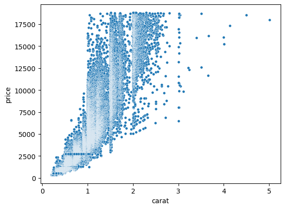

```python
sb.scatterplot(df, x = 'carat', y= 'price',    s = 15)
```

The relationship doesn't look very linear, carat^2 or carat^3 might come closer to a linear relationship with price. Let's look at what variables we have to work with.

```python
list(df.columns)
```

```
['carat', 'cut', 'color', 'clarity', 'depth', 'table', 'price', 'x', 'y', 'z']
```

It would be nice if we had a variable that was carat cubed or carat squared. Resist the urge to start writing some python code (it's hard, I know). We can create a data set consisting of price, carat, carat^2 and carat^3 using simple notation. Our design formula will be price + carat + I(carat**2) + I(carat**3). We'll use Patsy and the dmatrix function to do the work for us.

```python
df2 = dmatrix('price + carat + I(carat**2) + I(carat**3)', data = df, return_type = 'dataframe', NA_action=NAAction(NA_types=[]))

df2.head(10)
```

|  | Intercept | price | carat | I(carat ** 2) | I(carat ** 3) |
| --- | --- | --- | --- | --- | --- |
| 0 | 1.0 | 326.0 | 0.23 | 0.0529 | 0.012167 |
| 1 | 1.0 | 326.0 | 0.21 | 0.0441 | 0.009261 |
| 2 | 1.0 | 327.0 | 0.23 | 0.0529 | 0.012167 |
| 3 | 1.0 | 334.0 | 0.29 | 0.0841 | 0.024389 |
| 4 | 1.0 | 335.0 | 0.31 | 0.0961 | 0.029791 |
| 5 | 1.0 | 336.0 | 0.24 | 0.0576 | 0.013824 |
| 6 | 1.0 | 336.0 | 0.24 | 0.0576 | 0.013824 |
| 7 | 1.0 | 337.0 | 0.26 | 0.0676 | 0.017576 |
| 8 | 1.0 | 337.0 | 0.22 | 0.0484 | 0.010648 |
| 9 | 1.0 | 338.0 | 0.23 | 0.0529 | 0.012167 |

Not bad for what amounts to one line of code! The secret is in the I(...) that says to treat the contents of the parentheses as a set of arithmetic operations to be applied row-wise to the specified columns. The other parameters in the dmatrix function call tell dmatrix to get its data from the dataframe df, to return a dataframe, and to put in a NA marker where ever it cannot complete the transformation either because of because of missing data or numerical failure (e.g. division by 0).

Suppose that we want a variable that is the log of price

```python
df4 = dmatrix('np.log(price)', data = df, return_type = 'dataframe',NA_action=NAAction(NA_types=[]))
df4.head(10)
```

|  | Intercept | np.log(price) |
| --- | --- | --- |
| 0 | 1.0 | 5.786897 |
| 1 | 1.0 | 5.786897 |
| 2 | 1.0 | 5.789960 |
| 3 | 1.0 | 5.811141 |
| 4 | 1.0 | 5.814131 |
| 5 | 1.0 | 5.817111 |
| 6 | 1.0 | 5.817111 |
| 7 | 1.0 | 5.820083 |
| 8 | 1.0 | 5.820083 |
| 9 | 1.0 | 5.823046 |

Note, with any numpy function (with prefix np.) we can skip the I(). We can also do logical operations

```python
df5 = dmatrix('price + I((price >= 300) & (price <= 400))', data = df, return_type = 'dataframe',NA_action=NAAction(NA_types=[]))
print(df5.iloc[25:35])
```

```
    Intercept  I((price >= 300) & (price <= 400))[T.True]  price
25        1.0                                         1.0  354.0
26        1.0                                         1.0  355.0
27        1.0                                         1.0  357.0
28        1.0                                         1.0  357.0
29        1.0                                         1.0  357.0
30        1.0                                         0.0  402.0
31        1.0                                         0.0  402.0
32        1.0                                         0.0  402.0
33        1.0                                         0.0  402.0
34        1.0                                         0.0  402.0
```

By now, a world of transformations may be occurring to you. Here's a tricky one. Suppose that we would like to create binary variables for each outcome of a the variable color. Instead of a string variable with 7 entries 'D', 'E', ..., 'J' we would like 6 binary variables, one for each but one outcome. Simply put a C() around the variable in question (be careful not to do this with variables that take on a lot of values).

```python
df6 = dmatrix('price + carat + C(color)', data = df, return_type = 'dataframe',NA_action=NAAction(NA_types=[]))
df6.head(10)
```

|  | Intercept | C(color)[T.E] | C(color)[T.F] | C(color)[T.G] | C(color)[T.H] | C(color)[T.I] | C(color)[T.J] | price | carat |
| --- | --- | --- | --- | --- | --- | --- | --- | --- | --- |
| 0 | 1.0 | 1.0 | 0.0 | 0.0 | 0.0 | 0.0 | 0.0 | 326.0 | 0.23 |
| 1 | 1.0 | 1.0 | 0.0 | 0.0 | 0.0 | 0.0 | 0.0 | 326.0 | 0.21 |
| 2 | 1.0 | 1.0 | 0.0 | 0.0 | 0.0 | 0.0 | 0.0 | 327.0 | 0.23 |
| 3 | 1.0 | 0.0 | 0.0 | 0.0 | 0.0 | 1.0 | 0.0 | 334.0 | 0.29 |
| 4 | 1.0 | 0.0 | 0.0 | 0.0 | 0.0 | 0.0 | 1.0 | 335.0 | 0.31 |
| 5 | 1.0 | 0.0 | 0.0 | 0.0 | 0.0 | 0.0 | 1.0 | 336.0 | 0.24 |
| 6 | 1.0 | 0.0 | 0.0 | 0.0 | 0.0 | 1.0 | 0.0 | 336.0 | 0.24 |
| 7 | 1.0 | 0.0 | 0.0 | 0.0 | 1.0 | 0.0 | 0.0 | 337.0 | 0.26 |
| 8 | 1.0 | 1.0 | 0.0 | 0.0 | 0.0 | 0.0 | 0.0 | 337.0 | 0.22 |
| 9 | 1.0 | 0.0 | 0.0 | 0.0 | 1.0 | 0.0 | 0.0 | 338.0 | 0.23 |

Trick question: what happed to the variable for the outcome 'D'?

```python
df7 = dmatrix("price + carat + C(color,Treatment(reference='J'))", data = df, return_type = 'dataframe', NA_action=NAAction(NA_types=[]))
df6.head(10)
```

|  | Intercept | C(color)[T.E] | C(color)[T.F] | C(color)[T.G] | C(color)[T.H] | C(color)[T.I] | C(color)[T.J] | price | carat |
| --- | --- | --- | --- | --- | --- | --- | --- | --- | --- |
| 0 | 1.0 | 1.0 | 0.0 | 0.0 | 0.0 | 0.0 | 0.0 | 326.0 | 0.23 |
| 1 | 1.0 | 1.0 | 0.0 | 0.0 | 0.0 | 0.0 | 0.0 | 326.0 | 0.21 |
| 2 | 1.0 | 1.0 | 0.0 | 0.0 | 0.0 | 0.0 | 0.0 | 327.0 | 0.23 |
| 3 | 1.0 | 0.0 | 0.0 | 0.0 | 0.0 | 1.0 | 0.0 | 334.0 | 0.29 |
| 4 | 1.0 | 0.0 | 0.0 | 0.0 | 0.0 | 0.0 | 1.0 | 335.0 | 0.31 |
| 5 | 1.0 | 0.0 | 0.0 | 0.0 | 0.0 | 0.0 | 1.0 | 336.0 | 0.24 |
| 6 | 1.0 | 0.0 | 0.0 | 0.0 | 0.0 | 1.0 | 0.0 | 336.0 | 0.24 |
| 7 | 1.0 | 0.0 | 0.0 | 0.0 | 1.0 | 0.0 | 0.0 | 337.0 | 0.26 |
| 8 | 1.0 | 1.0 | 0.0 | 0.0 | 0.0 | 0.0 | 0.0 | 337.0 | 0.22 |
| 9 | 1.0 | 0.0 | 0.0 | 0.0 | 1.0 | 0.0 | 0.0 | 338.0 | 0.23 |

Suppose instead, we wanted a binary variable that is 1 if color is either 'I' or 'J'.

```python
df8 = dmatrix("I((color == 'I') | (color == 'J')) + color", data = df, return_type = 'dataframe', NA_action=NAAction(NA_types=[]))
df8.head(10)
```

|  | Intercept | I((color == 'I') \| (color == 'J'))[T.True] | color[T.E] | color[T.F] | color[T.G] | color[T.H] | color[T.I] | color[T.J] |
| --- | --- | --- | --- | --- | --- | --- | --- | --- |
| 0 | 1.0 | 0.0 | 1.0 | 0.0 | 0.0 | 0.0 | 0.0 | 0.0 |
| 1 | 1.0 | 0.0 | 1.0 | 0.0 | 0.0 | 0.0 | 0.0 | 0.0 |
| 2 | 1.0 | 0.0 | 1.0 | 0.0 | 0.0 | 0.0 | 0.0 | 0.0 |
| 3 | 1.0 | 1.0 | 0.0 | 0.0 | 0.0 | 0.0 | 1.0 | 0.0 |
| 4 | 1.0 | 1.0 | 0.0 | 0.0 | 0.0 | 0.0 | 0.0 | 1.0 |
| 5 | 1.0 | 1.0 | 0.0 | 0.0 | 0.0 | 0.0 | 0.0 | 1.0 |
| 6 | 1.0 | 1.0 | 0.0 | 0.0 | 0.0 | 0.0 | 1.0 | 0.0 |
| 7 | 1.0 | 0.0 | 0.0 | 0.0 | 0.0 | 1.0 | 0.0 | 0.0 |
| 8 | 1.0 | 0.0 | 1.0 | 0.0 | 0.0 | 0.0 | 0.0 | 0.0 |
| 9 | 1.0 | 0.0 | 0.0 | 0.0 | 0.0 | 1.0 | 0.0 | 0.0 |

For a somewhat more ambitious example, suppose we want to create a binary variable that is 1 if the price of that observation falls in the top 10 percent of all observed prices and 0 other wise. We'll use the np.percentile() function, coupled with the logic operators.

```python
df8 = dmatrix("I(price > np.percentile(price, 90)) + price", data = df, return_type = 'dataframe', NA_action=NAAction(NA_types=[]))
df8.head(10)
```

|  | Intercept | I(price > np.percentile(price, 90))[T.True] | price |
| --- | --- | --- | --- |
| 0 | 1.0 | 0.0 | 326.0 |
| 1 | 1.0 | 0.0 | 326.0 |
| 2 | 1.0 | 0.0 | 327.0 |
| 3 | 1.0 | 0.0 | 334.0 |
| 4 | 1.0 | 0.0 | 335.0 |
| 5 | 1.0 | 0.0 | 336.0 |
| 6 | 1.0 | 0.0 | 336.0 |
| 7 | 1.0 | 0.0 | 337.0 |
| 8 | 1.0 | 0.0 | 337.0 |
| 9 | 1.0 | 0.0 | 338.0 |

It's a bit difficult to see if this command really worked. The easiest way to exhibit the variable is to sum the created column.

```python
Nrow = sum(df8['Intercept'])
Nselectedrow = sum(df8['I(price > np.percentile(price, 90))[T.True]'])
print(f"Total number of rows: {Nrow} \nNumber of rows with price > 90th percentile: {Nselectedrow}")
```

```
Total number of rows: 53940.0
Number of rows with price > 90th percentile: 5393.0
```

```python
## Back to Data Wrangling
```

There are some un-addressed issues that remain.

The variable names that result from these transformations can be unwieldy. Patsy can't deal with very complex variable names. It's a bit ironic that Patsy makes up variable names that it cannot itself process....So it would be convenient to be able to rename variables on the fly.

When we make transformations we would generally like for the new columns to be added to our original set of columns. That's easily accomplished with another bit of Python. Simply use cat and axis = 1 to put the new columns in to the original data frame, but be careful not to duplicate columns (one good thing about Patsy's awkward naming convention is that it preserves the uniqueness of column names).

Transformations are nice, but filtering is nice also. Suppose we want a data set that contains data only for diamonds with the highest color rating? Yep, you guessed it, another bit of Python would take care of that.

These considerations led to goFilterData.py (accessed by clicking the Wrangle Data button). This code wraps a tkinter interface around the minimal amount of Python to accomplish all of the above tasks.

## Back to Data Wrangling

### New Variables from Old Variables

Dismissing all but the Data Wrangler window leaves us with

[figure not shown]

At the bottom of the window is a preview of your data. Clicking on the column headings will sort the data table on that variable: first click is increasing second is decreasing. Caution: for large data sets (>25K rows) this can take time. Moving to the top of the window, the first line displays the filename and path and the number of rows and columns in the dataframe. If you want to save a snapshot of your wrangled data, click "Save Data" and follow the dialogs. If you find yourself dissatisfied with your wrangled data, you can always start over by re-reading your data using DataGopher's Get Data button. In this case, I've asked for two new variables: carat squared and carat cubed. If I click "Add Variable". That's just what it will do:

[figure not shown]

### A non-obvious point.

The "Select Variables" choice menu allows you to choose some variable names to work with in the text box on the next line. You don't have to choose your variables this way, you can type whatever you want into the next line and Data Wrangle will try to process it. Selecting variable names is handy when the names are long or convoluted.

### Renaming Variables

Now let's use the "Rename Variables" frame to rename "I(carat**2)" to "carat_2". Select the variable name and then change the name that appears in the "New name" field to whatever you want. Click "Change Name" and here is what you should get:

[figure not shown]

### Filtering: Excluding Rows

Data wrangler offers two types of filters. Simple numerical filters or categorical filters. For a numerical variable a numerical filter allows you specify upper and lower bounds and wether the rows between the bounds or outside of the bounds are to be retained. You then click "Apply Filter" and it removes rows that did not meet the stated criterion. A categorical filter specifies a list of specific outcomes that will either be included or excluded. This is meant primarily for non-numerical variables that take on a relatively small number of distinct values. Sometimes it is also appropriate for numerical variables that discrete values (for example ZIP codes).

Start by clicking on the filter type and the variable on which to base the filter.

[figure not shown]

In the case depicted above I am going to filter on the "color" variable. Suppose that would like to look only at the rows for color "D" and "E". I will click "Default All excluded" this means we start with no outcomes for color chosen. Then I choose to include only the outcomes "D" and "E" by choosing from the "Add" dropdown list. The "Filtered Outcomes" field populates as I choose to add variables. In the window below I have chosen to move "D" from the excluded list to the included list (it shows up in the text area immediatly below the drop down lists) and am about to include "E" as well. Had I chosen "Default All Included" I would have started with all of the outcomes for color in the "Filtered Outcomes:" list and would have had to choose to remove everything but colors "D" and "E".

[figure not shown]

I then click "Apply Filter" and almost nothing changes. You can only tell that the data has been filtered by the fact that the number of rows indicated a the top of the Data Wrangler window has changed. The number of observations has dropped from 53940 to 16572.

[figure not shown]

Suppose that I only want to look at diamonds with sizes between .5 carats and 1.25 carats. This is easily accomplished with a numerical filter. First click "Cancel Filter" to get rid of the category filter, then choose "Numerical Filter", choose a variable, fill in the lower and upper bound and choose whether the rows are chosen from values inside the bounds ("Inside the speciied bounds"). *Important Note* "Cancel Filter" simply moves us back to the filter choice panel, it does not cancel the results of the most recent filter application.

[figure not shown]

The number of rows has fallen to 8985. If I've filtered myself into a corner, I can go back to the original data by reading it in again.

### Re-Shaping the Data

In the Diamonds data set each row represents the sale of a diamond, each column contains what we observed about that diamond. This implied structure is often assumed of statistical data, columns are observed characteristics each numerical observation in a column is given in the same units, rows correspond to (in the best case) randomly selected individuals from a population, numerical entries in a row need not be in the same units. While this seems like a quite flexible way to view data, it does restrict our view of the data. For example, every operation starts by specifing a column or columns on which the operation will be based.

Sometimes it is useful to be able to take a collection of columns and turn them into a single column (we'll use this when we get around to plotting below). This is where the "Re-Shape Data" panel comes in. The variables "x", "y" and "z" denote the length of the diamond along three axis. Each measurement is in millimeters. Suppose that I wish to create a variable that is the length along a dimension and a second categorical variable that takes on the values "x", "y", or "z" indicating which dimension the length measures and I would also like to preserve information on the color and clarity of the diamond that corresponds to the measurment.

We accomplish this by choosing "x", "y", and "z" as "Value Variables" and "color" and "clarity" the ID variables. The figure below shows the set up.

[figure not shown]

Now take a deep breath and click the "Do Re-Shape". Now we see a completely different data set:

[figure not shown]

Note there are now 26,955 rows (exactly 3 x 8985). The three columns have been "stacked" one ontop of the other to construct a variable called "value" and the variable called "variable" indicates which entry is an "x", a "y", or a "z". The choice of names is unimaginative, but that can be corrected by changing them. The color and clarity variables indicate the color and clarity of each entry. Pretty nifty, huh? But what is it good for? Stay tuned.

### Data Wrangling: More examples using creating, naming and filtering

#### In these examples I have suppressed the re-shape data window to make things more legible.

We can take advantage of the Patsy notation capability in the Data Wrangling module to do interesting things. Suppose that in our model of diamond prices we'd like to use a standardized weight quantity. We need to take each entry in the variable "carat" subtract the mean of all entries in the "carat" variable and divide it by the standard deviation of those entries. The new variable we could call "carat_standard_score". This is easily done. Here's the Data Wrangle Panel with the necessary commands and the output. The "ddof" parameter is the delta degrees of freedom parameter setting it equal to 1 amounts to dividing by n-1 when calculating the standard deviation.

[figure not shown]

Creating a "hold out" sample:

Suppose that we would like to create a random "hold out" sample. The idea is that we will identify a random selection of 33% of the rows in the data set. We will remove these rows and fit our model on the remaining rows. Once we have a model that we think works well on remaining 67% (this may involve much trial and error), we can test our model on the 33% we held aside. This is one strategy for dealing with the problem of "overfitting", i.e. obtaining a model that shows apparent good fit because it fits well the spurious idiosyncratic features of a specific sample.

First, let's return to the full length Diamonds data set (53,940 rows).

Start by creating a variable that takes on the values 1 for holdout and 0 for training. We want to make sure that the entry 1 occurs randomly in 33 % of the rows independent of the contents of a row. This is easily done with numpy as below the figure shows the combination of creating the new variable and renaming it. You would have to do this in two steps.

[figure not shown]

Now save this new data set from the Data Gopher panel. I'll call the file "Diamonds_with_hold.csv". Then read the data set back in the Wrangle Data app will automatically synchronize to the new data set,

[figure not shown]

At this point you can save the file, using a new file name for example, "Diamonds_holdout_data.csv".

Now repeat the process of reading in the file Diamonds_with_hold.csv but filter out the rows where the 'hold' variable is 1 (same as above but click for the Filter Action "Outside specified bounds"). Save that file as "Diamonds_training_data.csv".

You have now split the data set Diamonds.csv into Diamonds_holdout_data.csv and Diamonds_training_data.csv.

A fine point. After saving the training data, a different approach to isolating the training data would to read the original data back in generate a new 'hold' variable and the save just the rows with an entry of 0. The problem is that this will not give the same assignment of 0's and 1's to the rows as happened the first time we created a 'hold' variable. That means there could be (infact quite likely will be) rows that appear in both the training and the testing data. There are ways to fix this approach but they involve setting the seed number for the random number generator. That is not accessible from Patsy as far as I know.

Going back to our original data set (Diamonds.csv, 53940 rows), suppose that I wish to construct a variable that takes on the value 1 for those diamonds in the upper 25% of sales price per carat and 0 otherwise. Alteratively, we might say that these diamonds fell above the 75-th percentile of sales price per carat. This is easily done using Wrangle Data, the relevant window containing the command to construct the variable is shown below. Note that this command creates two variables, I(price_per_carat > np.percentile(price_per_carat,75))[False] which is 1 for diamonds not above the 75th percentile and 0 otherwise and I(price_per_carat > np.percentile(price_per_carat,75))[True] which is 1 for diamonds above the 75th percentile and 0 otherwise. I have renaned the latter variable high_price_per_carat. We will use this variable later in these notes.

[figure not shown]

### Missing Data: NaN or inf

Missing data is a pervasive but often overlooked problem. A missing entry in a column is usually indicated by the "nan" (equivalently "NaN" or "na") string, which technically stands for "not a number" but also seems to indicate missing qualitative variables. The natural approach is to simply remove rows with missing data. For some calculations, for example computing regression coefficients, or plotting data this is essential. You cannot do model fit calculations on data that does not exist, you cannot plot data that does not exist. If the missing data points are randomly distributed across the data set, this poses few problems. On the other hand, when the occurance of missing data is correlated with one or more of the characteristics measured in the data set, simply removing all rows with missing data can yield very misleading results. A classic example in the setting of a survey happens when a subject's likelihood of not responding to a question depends on the answer to that question. For example, when questioned about income, individuals at the low end of the income distribution may be more reticent to respond than individuals above the median of the population. When questioned about alcohol use, the opposite may happen (those at the high end of the consumption distribution may be reticent to respond). In this case, naively removing observations (rows) with missing data (indicating non-response to a survey question) may yield estimates of the population mean that are biased. We can analyize patterns in the missing data by creating a variable that is 1 if the column contains a missing data point in a particular row and O otherwise.

Sometimes, the transformations we make to the data (for example square root or logarithm) will create missing entries in the new column when the calculated transformation cannot be done or yield infinite values for some outcomes of the data. When Python thinks that the result of a calculation is either +infinity or -infinity it will return the string +inf or -inf (or +np.inf or -np.inf). Most calculations with infinite values can yield unpredictable result. Unfortunately, in a effort to be helpful, these calculations are often flagged only as a warning and not as an error. The result can be very peculiar results when fitting a model, and errors when trying to plot (infinity is very hard to depict in a finite plotting area).

#### How DataGopher Deals with na and inf

The presence of "nan" in data used to create a plot or fit a model will generally cause a failure. When doing operations on columns of data (for example variable transformations) the various Python commands are usually happy to skip over the entries containing na. This may vary by the particular transformation being attempted. When plotting or model fitting DataGopher will remove all rows containing na's. Dealing with inf's is a more subtle problem as sometimes no indication of difficulty is given until a warning message is produced during a model fit calculation. To make the process both clearer to the user and consistent, Datagopher will tolerate na's on input but will filter out rows with na values among the columns in the model or the columns to be plotted. It will also report how many rows have been deleted (this is in the default plot title and is also posted in the model fit report as well as the log). Datagopher will not tolerate inf's on input anywhere in the input data, or as a by-product of data transformations. On input the user will be told how many and in which columns the inf's occurred and will be offered the opportunity to convert inf's to na's. The thinking here is that inf's on input are the product of infelicities in the data preparation upstream of DataGopher and should be rectified before proceeding, however, converting inf's into na's and continuing is a stop gap for those users don't have time to re-wrangle the data. The rows with inf's in the relevant columns will be dropped before a model is fit or the data plotted (along with the other na's). If the user does not need the columns with the inf's for plotting or modeling, then the resulting plots/models will have the same number of input rows as if the columns with the inf's had not been present, if the user must employ the columns with the inf's the user has been given fair warning that additional rows have been deleted.

To illustrate the usefulness of analyzing missing data I've added two variables to the Diamonds data set. A variable "diff_xy" which is the difference between "x" and "y" and a variable called "sqrt_diff_xy" which is the square root of the difference between "x" and "y". You can see that there are lots of missing values in the "sqrt_diff_xy" column. In this case it's easy to see that the occurance of missing data follows a suspicious pattern. We can analyze the pattern by creating a new variable that is 1 if the entry in the "sqrt_diff_xy" is missing and 0 otherwise. I'll call it "sqrt_diff_xy_missing".

[figure not shown]

We can now use our grahical and pivoting tools to analyze where the missing values occur. As a general rule, it's always a good idea to investigate missing data rather than simply removing the rows containing missing entries. The DataGopher will not routinely remove rows with missing data without offering some indication either in a pop up window or in the log file. When computing models (linear and generalized linear regression), rows with missing data among the columns included in the model have to be removed. Removed rows will be noted in the log file. The number of observations is also noted in the model fit report. You can compare this number to the number of rows read in when you chose the data file. The second exception is when plotting data. There is no way to graph missing data. In that case the default plot title will indicate how many points were plotted out of how many rows were in the original data set.

## Plot Data

Unsurprisingly, the Plot Data button brings up tools for plotting data. The first thing you see is a simple window (below). Which asks you to identify which variables you would like to plot.

[figure not shown]

Python has a witheringly complex and detailed ecosystem of packages for graphing and plotting data. Everything you might ever think about (and a few things you might not consider) with regards to representing data. I collected only a few tools based on the matplotlib package (plotting in the sprirt of MatLab), and the Seaborn package. Plot Data implements a rudimentary interface to plot 1, 2 and 3 dimensional representations of your data.

Here is a brief outline of what's avaiable

- One Dimension
  - Histograms, with kernel density overlay
  - Box Plots
  - Empirical Cumulative Distribution Function (ECDF)
  - Faceted grids of all (or most) of the above
- Two Dimension
  - 2D scatter plots or line plots
  - 2D scatter facet plots
- Three Dimension
  - 3D scatter plots

All plots start with some numerical quantity to be plotted. Clicking on "Select Numerical Variables" will give a list of possibilities (non numeric variables excluded). As you choose variables the list build from left to right. One dimensional plots the leftmost variable controls the numerical values to be plotted. For two dimensional scatter plots the first variable is the x-axis variable and the second variable the y-axis variable. For three dimensions the first two variables are the independent variables (x and y) and the third variable will be the dependent variabe (z-axis). You can add more dependent variables to the right. Those variables can be plotted on top of the basic 2 or 3 dimensional scatter plot. The scale of the x axis (2D) or x and y axes (3D) are NOT adjusted as more variables are added to the plot. Multiple scalse on the y (for 2D) and z (for 3D) axes are not allowed. You may have to fiddle with the axis limits to get a picture that makes sense or rescale a variable using the Wrangle Data module.

You can also pick variables to control the color, shape of marker or row and column facets. These variables can be either numerical or non-numerical but cannot be one of the variables being plotted on an axis. The variable chosen to be plotted, the color variable, marker variable, row facet variable and column facet variable must all be distinct. Assigning one of them removes that choice from the available variables for the the others.

There are some limitations. You can use a variable to control the color of the markers and another variable to control the type of marker only when doing a 2D scatter plot. If you want a grid of plots where rows can correspond to one variable, the columns to the values of another variable and the color of the markers to yet a third variable. You can do this by choosing 2D scatter Grid Plot. In this case if a variable is specified to control the marker type, it is ignored (three factors is a lot, four is too much). 3D plotting does not allow for a grid plot. It will allow colors that depend on the value of a variable.

The button "Clear Last Variable" will do just that. The "Color Variable:" allows you to choose a variable to control the color of the dots in a scatter plot of the color of the lines in a line plot. The plot type will give a list of available plot types. Choosing a plot type will change the options available to you in the plot window. The set of options are choices of which variables you wish to control the type of marker used for a data point in a scatter plot and the variables to be used to designate the rows and columns of a grid of plots. For the marker and grid variables there is a limit on the number of outcomes the controlling variable may have. This limit is driven by the practicality of plotting rather than any built-in limitation. As you choose different plot types, you will be presented with a small number of options to decorate the plot these decorations also depend on the plot type. Throughout all plots you will be able to choose the axis labels and a plot title. If no title string is given the plot title will give the number of points plotted. If you can't see all of a plot, try clicking the green button at the upper lefthand corner of the plot window, that will expand the window to full screen. Tools for saving plots are embedded in the plot window.

Let's try some basic plots. Suppose that we wish to know if the high_price_carat variable we constructed is actually 1 for diamonds above the 75th percentile in price per carat and 0 for otherwise. Let's do a boxplot of the price_per_carat variable and color it with the high_price_per_carat variable.

We would expect to get higher box plot for the diamonds with a value of 1 and a lower boxplot for diamonds with a value of 0 for the high_price_per_carrot variable.

Here's the plot window filled in to create the plot:

[figure not shown]

Here's the picture:

[figure not shown]

The boxplots seem to show that the observations where high_price_per_carat equals 1 are uniformly higher than obeservations with high_price=per_carat = 0. It would be more convincing if we could give the users some direct visualization of the data. We can do this by adding a data "dither" on top of our box plot. What happens is that the values of the variable price_per_carat are plotted on top of the box plot. But instead of plotting the points in a straight vertical line, the points are randomly offset from the vertical line to give some visual representation of the density of the points. It's easier to see than explain. Choose the option "Dither" in the boxplot window. Here's the picture:

[figure not shown]

Much better. We could have done nearly the same thing with a histogram of price_per_carat colored with the variable high_price_per_carat. Simple choose "Histogram" and click "Plot It". Here's the plot.

[figure not shown]

Let's try something a little more complex. We'll use a boxplot grid to examine the relationship beteen color, cut and price per carat. Here's the plot window.

[figure not shown]

and the resulting plot

[figure not shown]

In the spirit of "anything worth doing is worth over-doing". Lets try an ambitious exercise in facet plotting, plot the relationship between carat and price (a scatter plot) for each possible clarity and cut value and color the dots with the color variable. On top of that show the OLS regression line of price on carat for each color, cut, and clarity combination. The filled out plot window is here

[figure not shown]

and the finished product is here

[figure not shown]

Admittedly, this is a lot. But you have to admit, its festive; and it shows what a facet plot does. It creates one scatter plot corresponding to each pair of values of the row and column variables. Clearly if the variables one uses for the rows and columns have lots of outcomes, the plot can get...well...busy. Best to use these options judiciously.

[figure not shown]

We reshaped the data into this:

[figure not shown]

With this re-shaped data set, plotting is now a routine matter. The plot window is below. Just for fun, I added a dithered data representation to the plot.

[figure not shown]

And the plot is:

[figure not shown]

There is no color legend, but the identities of the boxplots are clear from the x-axis labels. Of course, we can also display a grid of box plots, this time there will be three box plots in each grid cells. For example gridding by color and clarity yields;

[figure not shown]

This may not be the most informative plot, but it does give one a sense of what can be done.

[figure not shown]

I adjusted the scales to make the x and y limits agree (so the line y=x would be roughly 45 degrees), and increased the dot size a bit. Here's what it looks like:

[figure not shown]

Changing the scale meant that 2 points (one with a y value of 31.8 and another with a y value of 58.9) were dropped from the plot. Technically this may cause another missing data problem, and a more perfectly rigorous analysis would require investigating these two observations. However, for the purposes of displaying the relationship that we engineered into the data, the inaccuracy induced by dropping two outlier points seemes a small price to pay for a a more compelling picture. Admittedly,this is a "slippery slope". Readers with a passion for rigor may adjust the y scale to a maximum of 70 and see all the points.

### Scatter Plot Optons

You will note that for the 2D Scatter/Line plot and 3D Scatter plot options the variable window for dependent variables offers additional options. Immeadiately below the marker size slider is a question asking if you want to add the variable to the scatter plot, after that you can choose to summarize the data with a lines (or surfaces) of different types and colors. Choosing "-" as the line type results in no line being plotted.

The problem when using line plots to represent scatter plot data is that in the most common setting there may be multiple values of the dependent variable associated with single values of the independent variable or variables. To create a line plot representation one needs to summarize these multiple values into a single values. There are many ways to do this each one offering a different level of "smoothing". The options are listed under "Estimator/Smoother". The current choices are

- **None:** this will attempt to draw the chosen line plot through each point. Unless you know that there is only one value for the dependent variable for each indpedent variable value (as, for example, in time series data) this will lead to a fairly messy plot.
- **mean:** chooses the mean of the dependent variable values associated with a single value of the independent variables, or a pair of values of the independent variables
- **median:** chooses the mean of the dependent variable values associated with a single value of the independent variables, or a pair of values of the independent variables
- **loess:** calculates a local estimated scatter plot smoothing of the dependent variable. This is a popular "nonparemetric" apprach to smoothing data that fits a linear model at each point that takes a subset of close points of size equal to some fraction of the sample. This fraction is set in the "Loess Fraction" parameter. The smaller the fraction the fewer points nearby points are sampled. The algorithm used: "LOESS_2D routine of Cappellari et al. (2013b), which implements the multivariate LOESS algorithm of Cleveland & Devlin (1988)"
- **polynomial:** calculates a nth degree polynomial fit between the dependent and independent varible(s) and graphs it. The order of the polynomial is controlled by the "Polynomial Order" parameter.

Currently, confidence bounds are offered only for the polynomial smoothing.

## Models: Linear Models Tools

The Linear Models Tools window (hence forth "Models") allows you to choose a model to respresent your data. The choices are ordinary least squares (OLS), logistic regression, probit, Poisson, gamma and negative binomial. Our data set is probably most amenable to least squares modeling. Let's fit simple linear model to predict price as a function of carat. Click on the Dependent Variable drop down menu and select "price" for the Independent variable select carat. the model price ~ carat appears in the "Model:" text box. Make sure that OLS is selected and then click Run Model. You can see a regression report by clicking on the "Report" button. You can see a log file of what the regression fit process did by clicking on "Log". The specified models and reports are shown below.

**Note #1:**. The model interface for Linear Models is pickier than the interface for the data wrangling module. The dependent and independent variables must be chosen via the drop down menu. Once chosen, one can type in any syntatically correct patsy expression using those variable names. For example, if I choose "carat" as an independent variable, I can then type in I(carat**2) + I(carat**3). To summarize, if the variable names are NOT chosen with the "Independent Variables:" drop down menu, the Models module will not "see" them. But once it sees them you can modify them.

**Note #2:** The version of the models Model module used to make the graphics for this section was a little older than the current version of the code. There is a button labeled "Sync Data" in the upper lefthand corner of the Model window. This button is no longer there because data synchronization betwen modules is now automatic. Otherwise it works the same as the current version of the Model module.

[figure not shown]

The regression report is nice, but plots are even nicer (and hold an audience's attention much better). Linear Models also has some rudimentary plotting capabilities. These tools are specialized to displaying models and giving an informal visual check to diagnose possilbe violations of the assumptions of the model being fit. For models with one and two variables Linear Models will display the response function (fitted line), confidence intervals, and, for OLS, prediction intervals super imposed on the data scatter plot. It will also display the residuals and prediction graphed against any numerical column in the data set. Additionally, you can ask for a corrleation grid to look for correlations between variables (good for diagnosing multicolliearity), and standard leverage and influence plots to look effects of outliers.

Let's look at a plot of our linear model of diamond price. This brings us to a complexity in the Linear Models user interface.

[figure not shown]

Is there a non linearity in the data the could be better modeled by a non linear function of the dependent variables? Let's try fitting price on carat^3 (carat cubed). There are two ways to do this. One way would be to regress price on carat_3 which I created with the Wrangle Data module. Another way would be to transform the variable "by-hand" in the Models module. This choice exposes a subtle complexity in the DataGopher interface.

There is also a subtlety around what plots to display. This is best illustrated with a example. Suppose we run the simple regression of price on the cube of "carat" using the approach of altering the model formula "by hand". Here is the model input, report and a plot of the fitted model.

[figure not shown]

Well, the R2 (in the report) got a little better. The model plot shows the curvature we expect from a cubic model. Note that Linear Models graphed with carat on the x-axis, not carat cubed.

Let's perform the same exercise but use carat_3 as our independent variable.

[figure not shown]

The report looks identical. However the model plot looks much more linear. The reason is the units of the X-axis have changed to carats cubed.

**Note:** If you transform a variable using the equation field directly, the model is plotted in terms of the original variable. If your original data set contains the transformed variable, the model is plotted interms of the transformed variable. In a sense, the latter plot is a plot the model that the OLS fitting routing "sees". Which is better? That depends on what you want to do with the plot. If you want to display the non-linear relationship implied by your variable transformation and the fitted coefficients, the plot against the original variable might be helpful. On the other hand if you are interested in visually checking the OLS assumptions, the plot against the transformed variable is a more useful picture of the linear regression fit by the model. Perhaps the easiest way to "see" the scaling effect is to plot the residuals against carat then agains carat_3. The residuals don't change but their spacing on the x-axis does.

### Logistic Regression: Logit

When the dependent variable is binary, some different modeling techniques come into play. Linear Models offers two: logit and probit. These maximum likelihood techniques are based on two different models of the process generating the data. Earlier in these notes I created a binary variable which is 1 if the diamond in that observation was in the 75th percentile or above in sales price per carat and called it high_price_per_carat. The purpose of my logit model will be to predict which diamonds in the sample fall into the 75% of price per carat using carat, color, cut, clarity, and table. We can fit the logistic regression and plot the ROC curve (a visual indicator of the model's descriminatory power). A common summary measure of a logit model's ability to predict the response variable (in this case high_price_per_carat) is AUC which for Area-Under-the-Curve. The model achieved an astonishing 0.97507.

[figure not shown]

This was a suspiciously strong result, but perhaps not surprising as carat was used as an independent variable and is also part of th definition of high_price_per_carat. Let's look at some plots. One informative plot is a plot the predictions of the model (probabilities) and color them with the outcome and plot against one of the independent variables like so:

[figure not shown]

Note: Est. Mean Response means Estimated Mean Response. The response variable is either 0 or 1 (either not above 75th percentile or above 75th percentile) so mean response = probability that diamond is at or above the 75th percentile in price per carat. More sussinctly: for a logistic regression Est. Mean Response = estimate of P(esponse variable = 1).

## Data Pivot: Pivot Tables

The "Data Pivot" window starts by displaying the input data, much like the Data Filter window. It allows us to aggregate and display data in lots of different ways. It's most useful for data tha contains a mix of numerical and categorical data items. It functions generally like a spreadsheet data table with somewhat more explicit input. Categorical variables are used to populate the row indicies and column headings. The numerical values to be aggregated are specified in the Values text field. How the values are to be aggregated is specified in the Aggregation Functions text field.

[figure not shown]

Let's try a simple example. Suppose we'd like to calculate the median price of diamonds by color and cut. The row variable will be cut, the column variable color, the value will be price and the aggregation function will be median. Of course we'd like marginal medians for comparison (median of all cuts of a single color and median over all colors for a single cut). What we get looks somthing like this:

[figure not shown]

The plotting tools for pivot tables are fairly rudimentary. Choose a plot type and click a button. A bar chart might make sense here. The legend can be a bit of a problem, overlapping some of the plot. You may need to resize the plot to make it legible. To do: allow the user to rotate the x-axis labels; allow user to input a chart title.

[figure not shown]

Of course, just as with spreadsheet, pivot tables can do much more. Multiple row and column categories can be specified, multiple values to aggregate and multiple aggregation functions. This leads to compound row and column indices and a much larger table. For example:

[figure not shown]

Complex pivot table specifications can easily lead to tables that are difficult to read, even harder to interpret of which only a small fraction can be displayed on the screen. Moderation is a virtue when specifying pivot tables.

Of course any table that can be displayed can be plotted in multiple ways. The moderation advice applies to plots also. If you choose a plot type and then click on plot, the program will dutifully try to plot the pivot table, or give up and complain. For example choosing Line Plot and clicking plot on the mess in the table above yields:

[figure not shown]

a plot that leaves a bit to be desired in terms of legibilty.

**Note:** As of this writing, I have reverted to a monospace text prepresentation of the pivot table. I am working on displaying tables with multi-variable columns but have been unable to change the height of the column name row. The text representation uses less screen space and shows multi-indices for rows and columns appropriately. And it gives a sort of retro-tech-cool vibe.

### Important But Somewhat Tedious Details

Original intent of DataGopher was to be a minimal set of, largely independent, component applications to support basic data wrangling and exploratory statistical modeling via a ``simple'' graphical user interface. This is sometimes now called "unsupervised learning" in the sense that the user may be at the stage of sorting out what sort of model to use rather than testing a specific model formulation. As such, an important design goal was to support a trial-and-error approach to graphics and modeling. I have tried to keep annoying pop-up window advice to a minimum.

Each of the buttons "Wrangle Data", "Pivot Data", "Plot Data" and "Models" corresponds to a separate tkinter class and each can be run as a stand alone app with minimal shared resources If you look below the "if **name** == "**main**":" line in each of the files corresponding to these four main functions ("goDataFilter.py", "goPivotb.p", "goPlot.py", "goModel.py" respectively), you will see the code that runs the corresponding app in standalone mode. The files "Graphics.py", "Regression.py", "globalData.py", "TableDisplaya.py", "TableDisplayb.py", and "Listwidget.py" contain the common resources needed by all of the four stand alone programs (in addition to a fairly standard set of imports). It is quite possible to run each of the four main applications separately simply invoke the corresponding python file instead of DataGopher.py.

In order to prevent incomplete or numerically invalid model fits, I have been somewhat finicky about what constitutes a successful model fit. Specifically, all runtime warnings are treated as errors and will report a fit failure. This is an attempt to avoid a situation where the model fit returns a report with lots of NA values. It's difficult to have confidence in the parameter estimates when the model fit function returns coefficient values but at the same time returns NA for standard error. This can happen when the model fit function runs into divide-by-0 conditions while fitting the model. When DataGopher receives a runtime warning or an error of any sort, it stops. It does not stop for language deprecation warnings, future code compatibilty warnings, etc..

#### Pro Tips

Any tool that allows for rapid trial and error and model iteration runs the risk of the user finding a plot or a model they would like to reproduce but with little or no recollection of how they got to the model or plot. This begs the question of how can one double-check DataGopher? How do we verify that the analysis is what we think it is, and how can we replicate that analysis outside fo DataGopher? This is an issue that has gained greater salience as AI analytical assistance has gained popularity. As of this writing, reproducability and verifiability are weaknesses in the AI assisted analytical workflow. I mean this as no knock on AI tools, I have used them to produce this code. But the purpose of AI is to learn from experience, and my data analysis task becomes part of my AI assistant's experience. I should expect no more consistency than I would from a human co worker.

DataGopher has some built in tools for verification and reproduction of results. First of all, DataGopher keeps a date and time stamped log of everything it does. Second, you can save the data that a model was fit on (e.g. after any rows with relevant missing data are removed), you can do the same for plots. This feature is particularly useful if you have had to do some data wrangling to get the results you want. What ever you may have done to the data ... or more politely ... however you may have curated the data ... you can save a copy of what data was used to fit the model or make a plot. For models, you can also save a copy of the input data with the model predictions, residuals and confidence intervals.

A second feature that is still under development is code generation. DataGopher generates python code to run any model fit or plot from scratch using only standard libraries (numpy,pandas, matplotlib, statsmodels, seaborn etc.). When you click on "Save Code" from the original button window the code for a plotting or model fitting session is saved in a text file . The resulting python should be runnable in python without (much) editing. As currently configured, the python script produced reads the original data in. If you wish to apply the script to a different file you can change the input file path in the script. If you have filtered the original data or created new variables, I suggest saving the changed data and then re-loading the changed data set before plotting and modelling. The code generation procedure for plotting is also useful when you find that my choices of default formatting do not suit your needs. Since the code is a mixture of plain matplotlib and seaborn, it is pretty easy to modify. There is some boilerplate code at the top of the script file that imports the necessary python packages, and one include file called "Graphics.py" that contains some helper functions for plotting. The file "Graphics.py" must be accessible to the generated code script, this is most easily accomplished by putting them in the same directory. If you want to create a single stand-alone script, simply copy the functions in Graphics.py into the generated script file.

One important point that may be obvious to python programmers. DataGopher depends on a collection of packages that must be installed in your python environment. If a critical import is missing, DataGopher or the code that DataGopher produces will stop and experess it's discontent with the selection of imports on offer in your python environment. If the last three sentences makes no sense to you, this might be a good time to learn about python environments, python package managers (conda or PIP) and import files. Alternatively, there is an application version of DataGopher that bundles all of the needed resources together (currently only available for Apple silicon a.k.a M-series) Macs. This app is packaged by pyInstaller, requires about 350MB of disc space, and several minutes to start. You will have to fiddle with your Mac's security settings to use it.

** Tip No. 1 ** If you want to do data wrangling before plotting and fitting models save the wrangled data and then read in the wrangled data for modeling and plotting. That way you have a copy of the exact data used to produce the plots and fit the data.

** Tip No. 2 ** If you are impatient with tip No. 1 you can run the analysis and plotting on the wrangled data after saving it and then change the file path to the wrangled data in the generated script file. This only works if you save the code.

** Tip No. 3 ** For the truely impatient, when you wrangle data with goDataFilter.py, the data is automatically updated in the other modules so that you can move freely back and forth between modeling, plotting, pivot tables, and more data wrangling. Each update will clear the information in the other modules' interfaces so be sure you remember the model you wanted to fit or plot you wanted to make. While this approach is quicker and more convenient, you can lose track of things pretty easily. I do this, I often regret it.

## Download the Application (M-series Macs only)##

Download the folder "app" from the repository on GitHub from which this document originated. Open the folder "app" and then "dist" and then double click on DataGopher.

## Jupyter Notebook or Jupyter Lab

Start Jupyter Notebook or Jupyter Lab, navigate to the 'srcnew directory' and open either the file "run_DataGopher_jupyter.ipynb" or "run_DataGopher_min.ipynb". The cells in these two notebooks show you how to invoke DataGopher from Jupyter Notebook or Jupyter Lab and how to find the main storage object containing the variables used by DataGopher.

## DIY

Download the contents of the 'srcnew' directory to you local computer. Navigate to your favorite Python development environment (Spyder, VSCode, IDLE3, etc.). Then launch DataGopher.py. Because DataGopher is a Tkinter app, it had it's own event loop that may conflict with your development environment. You may have to fiddle with the matplotlib backend and your settings to get it to work conveniently.